# QK Box 12.5

Parkinson et al. (2002) examined the differences in the abundance of birds between different habitats on a floodplain. Habitat was a between-subjects factor, and there were three groups: permanent billabongs, temporary billabongs, and non-wetland habitat. Four sites (subjects) were chosen within each habitat group. The authors were also interested in whether the pattern between habitats was consistent over months (austral summer: November, December, January, February) and time of the day (morning and evening chorus), so each site was sampled morning and evening on one day each month; month and time of day were the crossed within-subjects factors. The relative abundance of birds was the response variable.

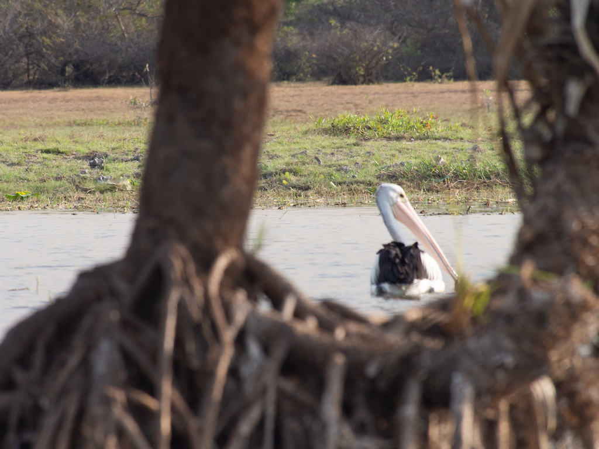

Australian Pelican, *Pelecanus conspicillatus.* Mick Keough, CC BY-SA 4.0.

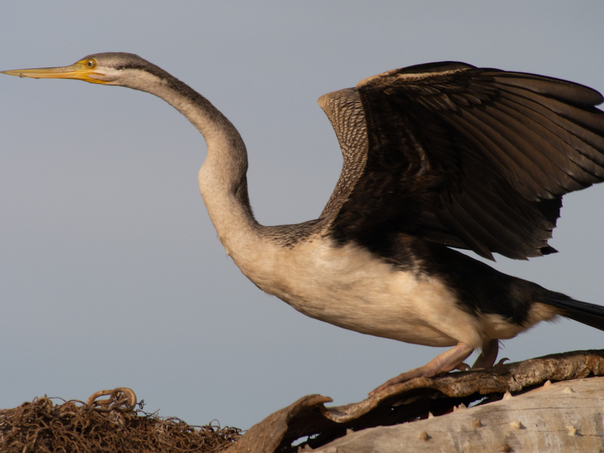

Australasian Darter, *Anhinga novaehollandiae.* Mick Keough, CC BY-SA 4.0.

Link to paper and data

Parkinson, A., Mac Nally, R. & Quinn, G. P. (2002). Differential macrohabitat use by birds on the unregulated Ovens River floodplain of southeastern Australia. *River Research and Applications*, 18, 495-506.

### Preliminaries

First, load the required packages (afex, car, lattice, lme4, lmerTest, nlme, VCA, ez, emmeans, Rmisc, MuMIn)

Import parkinson data file

```r
parkinson <- read.csv("../data/park2002.csv")
head(parkinson,10)
```

|  | habitat | bong | ampm | month | abund |
| --- | --- | --- | --- | --- | --- |
| 1 | perm | a | am | nov | 27 |
| 2 | perm | b | am | nov | 27 |
| 3 | perm | c | am | nov | 33 |
| 4 | perm | d | am | nov | 31 |
| 5 | temp | e | am | nov | 55 |
| 6 | temp | f | am | nov | 75 |
| 7 | temp | g | am | nov | 36 |
| 8 | temp | h | am | nov | 29 |
| 9 | wood | i | am | nov | 12 |
| 10 | wood | j | am | nov | 13 |

Set contrasts using afex

```r
set_sum_contrasts()
```

### Check residuals - uneven spread related to mean

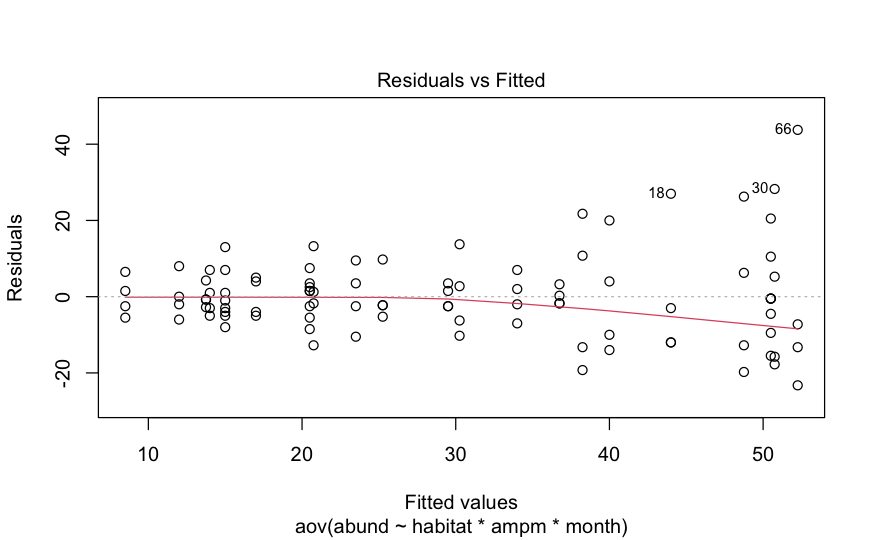

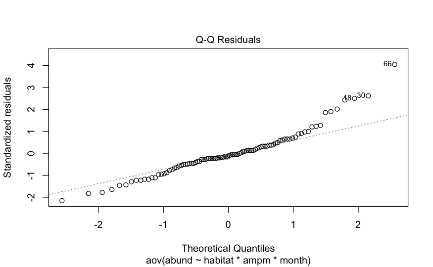

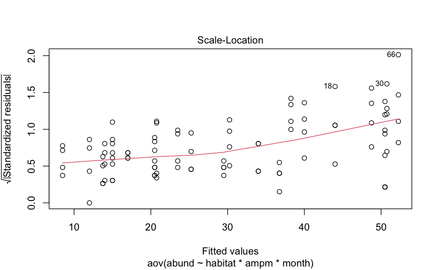

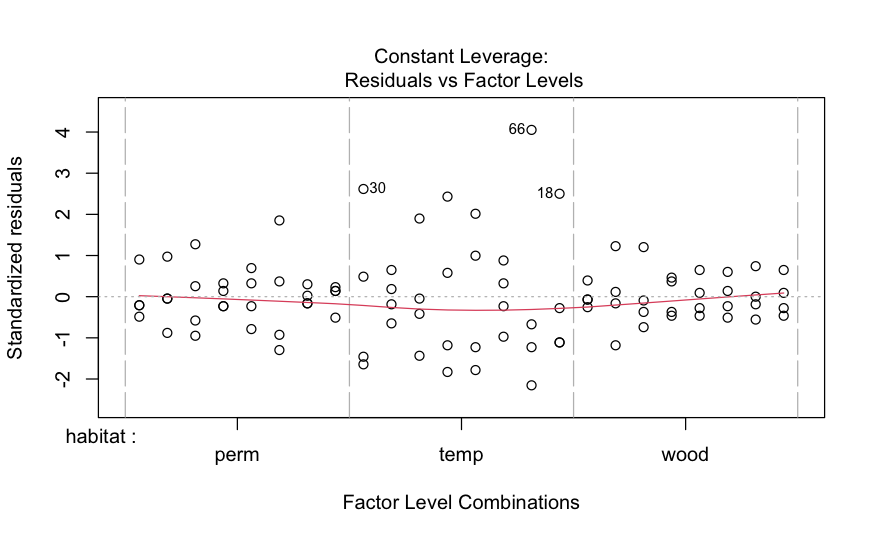

```r
park1.aov <- aov(abund~habitat*ampm*month, parkinson)
plot(park1.aov)
```

Unequal spread

### Original authors used 4th root transform but we will use log10 here

By now, you should be able to run your own version of this analysis with 4th root transform.

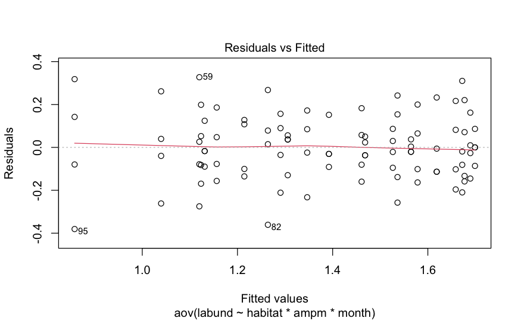

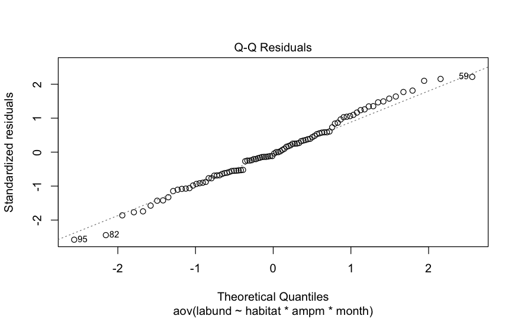

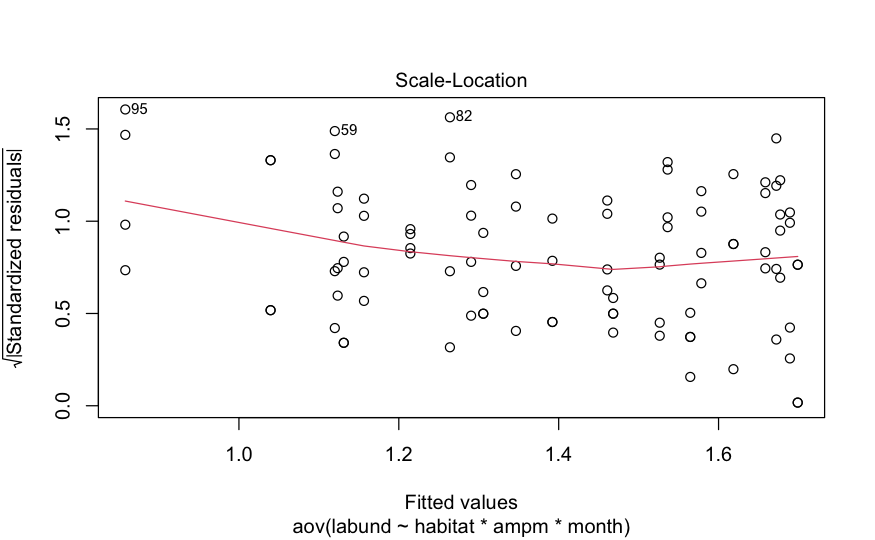

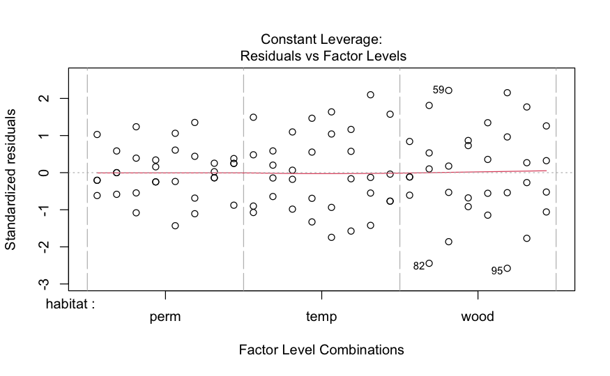

```r
parkinson$labund <- log10(parkinson$abund)
park2.aov <- aov(labund~habitat*ampm*month, parkinson)
plot(park2.aov)
```

Log10 improves spread in residual plot

## Run as split-plot

```r
park3.aov <- aov(labund~habitat*month*ampm+Error(bong/(month*ampm)), parkinson)
summary(park3.aov)
```

```
Error: bong
          Df Sum Sq Mean Sq F value   Pr(>F)
habitat    2  3.941  1.9705    36.6 4.76e-05 ***
Residuals  9  0.485  0.0538
---
Signif. codes:  0 ‘***’ 0.001 ‘**’ 0.01 ‘*’ 0.05 ‘.’ 0.1 ‘ ’ 1

Error: bong:month
              Df Sum Sq Mean Sq F value Pr(>F)
month          3 0.0597 0.01990   0.717 0.5502
habitat:month  6 0.7201 0.12002   4.326 0.0035 **
Residuals     27 0.7490 0.02774
---
Signif. codes:  0 ‘***’ 0.001 ‘**’ 0.01 ‘*’ 0.05 ‘.’ 0.1 ‘ ’ 1

Error: bong:ampm
             Df  Sum Sq Mean Sq F value Pr(>F)
ampm          1 0.24433 0.24433   9.273 0.0139 *
habitat:ampm  2 0.01888 0.00944   0.358 0.7084
Residuals     9 0.23714 0.02635
---
Signif. codes:  0 ‘***’ 0.001 ‘**’ 0.01 ‘*’ 0.05 ‘.’ 0.1 ‘ ’ 1

Error: bong:month:ampm
                   Df Sum Sq Mean Sq F value Pr(>F)
month:ampm          3 0.1755 0.05849   2.534 0.0779 .
habitat:month:ampm  6 0.1432 0.02386   1.034 0.4253
Residuals          27 0.6231 0.02308
---
Signif. codes:  0 ‘***’ 0.001 ‘**’ 0.01 ‘*’ 0.05 ‘.’ 0.1 ‘ ’ 1
```

Run with ezANOVA to get GG and HF adjustments

```r
ezpark1 <- ezANOVA(data=parkinson, dv=labund, wid=bong, within=month*ampm, between=habitat, type=3, detailed=TRUE)
print(ezpark1)
```

```
$ANOVA
              Effect DFn DFd          SSn       SSd            F            p p<.05         ges
1        (Intercept)   1   9 185.82587994 0.4845966 3451.1861758 6.044855e-13     * 0.988857661
2            habitat   2   9   3.94109825 0.4845966   36.5973345 4.756581e-05     * 0.653044220
3              month   3  27   0.05970429 0.7489888    0.7174187 5.502357e-01       0.027723404
5               ampm   1   9   0.24432786 0.2371379    9.2728783 1.390178e-02     * 0.104494288
4      habitat:month   6  27   0.72010127 0.7489888    4.3264409 3.495319e-03     * 0.255902542
6       habitat:ampm   2   9   0.01888359 0.2371379    0.3583408 7.083704e-01       0.008937925
7         month:ampm   3  27   0.17547497 0.6231424    2.5343723 7.791341e-02       0.077324211
8 habitat:month:ampm   6  27   0.14317702 0.6231424    1.0339477 4.252937e-01       0.064002814

$`Mauchly's Test for Sphericity`
              Effect         W          p p<.05
3              month 0.7890302 0.87321554
4      habitat:month 0.7890302 0.87321554
7         month:ampm 0.2455222 0.05655546
8 habitat:month:ampm 0.2455222 0.05655546

$`Sphericity Corrections`
              Effect       GGe       p[GG] p[GG]<.05       HFe       p[HF] p[HF]<.05
3              month 0.8526384 0.530946777           1.2200581 0.550235681
4      habitat:month 0.8526384 0.006128013         * 1.2200581 0.003495319         *
7         month:ampm 0.5380760 0.121213461           0.6382668 0.110170806
8 habitat:month:ampm 0.5380760 0.411016520           0.6382668 0.415745122
```

#### Draw bar graph

Pool times as time didn’t interact with anything

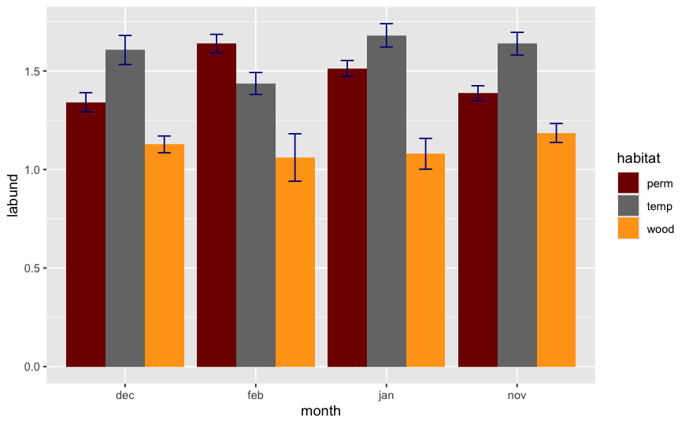

```r
park_stats <- summarySE(parkinson,measurevar='labund', groupvars= c('habitat','month'))
ggplot(park_stats, aes(x=month, y=labund, fill=habitat))+
  geom_bar(stat="identity", position=position_dodge())+
  geom_errorbar(aes(ymin=labund-se, ymax=labund+se), position=position_dodge(0.9), width=0.3, color="darkblue")+
  scale_fill_uchicago()
```

## Run as mixed effects with lme4

```r
park1.lmer <- lmer(labund~habitat+month+ampm+habitat*month+habitat*ampm+month*ampm+habitat*month*ampm+(1|bong)+(1|bong:month)+(1|bong:ampm), parkinson)
summary(park1.lmer, ddf="Kenward-Roger")
```

```
Linear mixed model fit by REML. t-tests use Kenward-Roger's method ['lmerModLmerTest']
Formula: labund ~ habitat + month + ampm + habitat * month + habitat *
    ampm + month * ampm + habitat * month * ampm + (1 | bong) +      (1 | bong:month) + (1 | bong:ampm)
   Data: parkinson

REML criterion at convergence: 30.9

Scaled residuals:
     Min       1Q   Median       3Q      Max
-2.32462 -0.45772 -0.02583  0.43892  1.99277

Random effects:
 Groups     Name        Variance  Std.Dev.
 bong:month (Intercept) 0.0023301 0.04827
 bong:ampm  (Intercept) 0.0008171 0.02858
 bong       (Intercept) 0.0028547 0.05343
 Residual               0.0230796 0.15192
Number of obs: 96, groups:  bong:month, 48; bong:ampm, 24; bong, 12

Fixed effects:
                       Estimate Std. Error        df t value Pr(>|t|)
(Intercept)            1.391289   0.023683  9.000000  58.746 6.05e-13 ***
habitat1               0.078617   0.033493  9.000000   2.347 0.043500 *
habitat2               0.199321   0.033493  9.000000   5.951 0.000215 ***
month1                -0.032860   0.029443 27.000000  -1.116 0.274232
month2                -0.012602   0.029443 27.000000  -0.428 0.672037
month3                 0.033117   0.029443 27.000000   1.125 0.270581
ampm1                  0.050449   0.016567  9.000000   3.045 0.013901 *
habitat1:month1       -0.095749   0.041638 27.000000  -2.300 0.029437 *
habitat2:month1        0.048929   0.041638 27.000000   1.175 0.250218
habitat1:month2        0.181415   0.041638 27.000000   4.357 0.000171 ***
habitat2:month2       -0.141554   0.041638 27.000000  -3.400 0.002112 **
habitat1:month3        0.009678   0.041638 27.000000   0.232 0.817961
habitat2:month3        0.057023   0.041638 27.000000   1.369 0.182134
habitat1:ampm1        -0.015329   0.023429  9.000000  -0.654 0.529298
habitat2:ampm1        -0.003236   0.023429  9.000000  -0.138 0.893183
month1:ampm1          -0.008753   0.026856 27.000000  -0.326 0.746987
month2:ampm1           0.067314   0.026856 27.000000   2.506 0.018519 *
month3:ampm1          -0.051518   0.026856 27.000000  -1.918 0.065702 .
habitat1:month1:ampm1  0.024475   0.037980 27.000000   0.644 0.524745
habitat2:month1:ampm1  0.031960   0.037980 27.000000   0.841 0.407460
habitat1:month2:ampm1 -0.042139   0.037980 27.000000  -1.110 0.276997
habitat2:month2:ampm1 -0.024581   0.037980 27.000000  -0.647 0.522957
habitat1:month3:ampm1 -0.035500   0.037980 27.000000  -0.935 0.358222
habitat2:month3:ampm1  0.012819   0.037980 27.000000   0.338 0.738333
---
Signif. codes:  0 ‘***’ 0.001 ‘**’ 0.01 ‘*’ 0.05 ‘.’ 0.1 ‘ ’ 1
```

```
Correlation matrix not shown by default, as p = 24 > 12.
Use print(x, correlation=TRUE)  or
    vcov(x)        if you need it
```

```r
anova(park1.lmer, ddf="Kenward-Roger")
```

```
Type III Analysis of Variance Table with Kenward-Roger's method
                    Sum Sq Mean Sq NumDF DenDF F value    Pr(>F)
habitat            1.68926 0.84463     2     9 36.5963 4.757e-05 ***
month              0.04967 0.01656     3    27  0.7174  0.550230
ampm               0.21402 0.21402     1     9  9.2731  0.013901 *
habitat:month      0.59912 0.09985     6    27  4.3265  0.003495 **
habitat:ampm       0.01654 0.00827     2     9  0.3583  0.708365
month:ampm         0.17547 0.05849     3    27  2.5343  0.077916 .
habitat:month:ampm 0.14318 0.02386     6    27  1.0339  0.425301
---
Signif. codes:  0 ‘***’ 0.001 ‘**’ 0.01 ‘*’ 0.05 ‘.’ 0.1 ‘ ’ 1
```

Get variance components

```r
park1.ci <- confint.merMod(park1.lmer, oldNames=FALSE)
```

```
Computing profile confidence intervals ...
```

```r
park1.vc <- (park1.ci)^2
print(park1.vc)
```

```
                                 2.5 %       97.5 %
sd_(Intercept)|bong:month 0.0000000000 9.205968e-03
sd_(Intercept)|bong:ampm  0.0000000000 7.721817e-03
sd_(Intercept)|bong       0.0000000000 1.000865e-02
sigma                     0.0112715453 2.597718e-02
(Intercept)               1.8161607435 2.059021e+00
habitat1                  0.0002856626 1.969313e-02
habitat2                  0.0189354222 6.814016e-02
month1                    0.0070893803 3.414726e-04
month2                    0.0040883970 1.500544e-03
month3                    0.0003320442 7.132707e-03
ampm1                     0.0003968621 6.557028e-03
habitat1:month1           0.0283428708 5.357182e-04
habitat2:month1           0.0005605165 1.477017e-02
habitat1:month2           0.0118397560 6.452538e-02
habitat2:month2           0.0458635686 4.754101e-03
habitat1:month3           0.0039597034 6.770270e-03
habitat2:month3           0.0002427766 1.680304e-02
habitat1:ampm1            0.0034223958 7.751915e-04
habitat2:ampm1            0.0021537385 1.594814e-03
month1:ampm1              0.0030904695 1.450516e-03
month2:ampm1              0.0004192180 1.303078e-02
month3:ampm1              0.0096741040 2.189676e-05
habitat1:month1:ampm1     0.0017443317 8.229206e-03
habitat2:month1:ampm1     0.0011751096 9.643298e-03
habitat1:month2:ampm1     0.0117459953 5.808691e-04
habitat2:month2:ampm1     0.0082484957 1.735467e-03
habitat1:month3:ampm1     0.0103510775 9.449429e-04
habitat2:month3:ampm1     0.0028537899 6.250372e-03
```

### Evaluate whether to keep site within habitat by ampm or by month interactions (use ML)

```r
park1a.lmer <- lmer(labund~habitat+month+ampm+habitat*month+habitat*ampm+month*ampm+habitat*month*ampm+(1|bong)+(1|bong:month)+(1|bong:ampm), REML=FALSE,parkinson)
park2.lmer <- lmer(labund~habitat+month+ampm+habitat*month+habitat*ampm+month*ampm+habitat*month*ampm+(1|bong)+(1|bong:month), REML=FALSE, parkinson)
park3.lmer <- lmer(labund~habitat+month+ampm+habitat*month+habitat*ampm+month*ampm+habitat*month*ampm+(1|bong)+(1|bong:ampm), REML=FALSE, parkinson)
anova(park1a.lmer, park2.lmer)
```

```
Data: parkinson
Models:
park2.lmer: labund ~ habitat + month + ampm + habitat * month + habitat * ampm + month * ampm + habitat * month * ampm + (1 | bong) + (1 | bong:month)
park1a.lmer: labund ~ habitat + month + ampm + habitat * month + habitat * ampm + month * ampm + habitat * month * ampm + (1 | bong) + (1 | bong:month) + (1 | bong:ampm)
            npar     AIC    BIC logLik deviance  Chisq Df Pr(>Chisq)
park2.lmer    27 -44.529 24.708 49.265  -98.529
park1a.lmer   28 -42.610 29.192 49.305  -98.610 0.0807  1     0.7763
```

```r
anova(park1a.lmer, park3.lmer)
```

```
Data: parkinson
Models:
park3.lmer: labund ~ habitat + month + ampm + habitat * month + habitat * ampm + month * ampm + habitat * month * ampm + (1 | bong) + (1 | bong:ampm)
park1a.lmer: labund ~ habitat + month + ampm + habitat * month + habitat * ampm + month * ampm + habitat * month * ampm + (1 | bong) + (1 | bong:month) + (1 | bong:ampm)
            npar     AIC    BIC logLik deviance  Chisq Df Pr(>Chisq)
park3.lmer    27 -44.306 24.931 49.153  -98.306
park1a.lmer   28 -42.610 29.192 49.305  -98.610 0.3041  1     0.5813
```

```r
AICc(park1a.lmer, park2.lmer, park3.lmer)
```

|  | df | AICc |
| --- | --- | --- |
| park1a.lmer | 28 | -18.37116 |
| park2.lmer | 27 | -22.29397 |
| park3.lmer | 27 | -22.07056 |

### Neither contribute to model fit, refit model without them

```r
park4.lmer <- lmer(labund~habitat+month+ampm+habitat*month+habitat*ampm+month*ampm+habitat*month*ampm+(1|bong), REML=FALSE, parkinson)
anova(park1a.lmer, park4.lmer)
```

```
Data: parkinson
Models:
park4.lmer: labund ~ habitat + month + ampm + habitat * month + habitat * ampm + month * ampm + habitat * month * ampm + (1 | bong)
park1a.lmer: labund ~ habitat + month + ampm + habitat * month + habitat * ampm + month * ampm + habitat * month * ampm + (1 | bong) + (1 | bong:month) + (1 | bong:ampm)
            npar     AIC    BIC logLik deviance  Chisq Df Pr(>Chisq)
park4.lmer    26 -46.299 20.374 49.150  -98.299
park1a.lmer   28 -42.610 29.192 49.305  -98.610 0.3109  2      0.856
```

```r
AICc(park1a.lmer, park2.lmer, park3.lmer, park4.lmer)
```

|  | df | AICc |
| --- | --- | --- |
| park1a.lmer | 28 | -18.37116 |
| park2.lmer | 27 | -22.29397 |
| park3.lmer | 27 | -22.07056 |
| park4.lmer | 26 | -25.95120 |

## Refit simpler model with REML

```r
park4a.lmer <- lmer(labund~habitat+month+ampm+habitat*month+habitat*ampm+month*ampm+habitat*month*ampm+(1|bong), parkinson)
summary(park4a.lmer, ddf="Kenward-Roger")
```

```
Linear mixed model fit by REML. t-tests use Kenward-Roger's method ['lmerModLmerTest']
Formula: labund ~ habitat + month + ampm + habitat * month + habitat *
    ampm + month * ampm + habitat * month * ampm + (1 | bong)
   Data: parkinson

REML criterion at convergence: 31.1

Scaled residuals:
     Min       1Q   Median       3Q      Max
-2.45047 -0.51655 -0.04362  0.53175  1.97897

Random effects:
 Groups   Name        Variance Std.Dev.
 bong     (Intercept) 0.003538 0.05948
 Residual             0.025544 0.15982
Number of obs: 96, groups:  bong, 12

Fixed effects:
                       Estimate Std. Error        df t value Pr(>|t|)
(Intercept)            1.391289   0.023683  9.000000  58.747 6.04e-13 ***
habitat1               0.078617   0.033493  9.000000   2.347 0.043497 *
habitat2               0.199321   0.033493  9.000000   5.951 0.000215 ***
month1                -0.032860   0.028253 63.000000  -1.163 0.249199
month2                -0.012602   0.028253 63.000000  -0.446 0.657104
month3                 0.033117   0.028253 63.000000   1.172 0.245557
ampm1                  0.050449   0.016312 63.000000   3.093 0.002954 **
habitat1:month1       -0.095749   0.039956 63.000000  -2.396 0.019539 *
habitat2:month1        0.048929   0.039956 63.000000   1.225 0.225301
habitat1:month2        0.181415   0.039956 63.000000   4.540 2.59e-05 ***
habitat2:month2       -0.141554   0.039956 63.000000  -3.543 0.000752 ***
habitat1:month3        0.009678   0.039956 63.000000   0.242 0.809405
habitat2:month3        0.057023   0.039956 63.000000   1.427 0.158481
habitat1:ampm1        -0.015329   0.023069 63.000000  -0.664 0.508801
habitat2:ampm1        -0.003236   0.023069 63.000000  -0.140 0.888885
month1:ampm1          -0.008753   0.028253 63.000000  -0.310 0.757725
month2:ampm1           0.067314   0.028253 63.000000   2.383 0.020225 *
month3:ampm1          -0.051518   0.028253 63.000000  -1.823 0.072981 .
habitat1:month1:ampm1  0.024475   0.039956 63.000000   0.613 0.542385
habitat2:month1:ampm1  0.031960   0.039956 63.000000   0.800 0.426787
habitat1:month2:ampm1 -0.042139   0.039956 63.000000  -1.055 0.295623
habitat2:month2:ampm1 -0.024581   0.039956 63.000000  -0.615 0.540635
habitat1:month3:ampm1 -0.035500   0.039956 63.000000  -0.888 0.377662
habitat2:month3:ampm1  0.012819   0.039956 63.000000   0.321 0.749402
---
Signif. codes:  0 ‘***’ 0.001 ‘**’ 0.01 ‘*’ 0.05 ‘.’ 0.1 ‘ ’ 1
```

```
Correlation matrix not shown by default, as p = 24 > 12.
Use print(x, correlation=TRUE)  or
    vcov(x)        if you need it
```

```r
anova(park4a.lmer, ddf="Kenward-Roger")
```

```
Type III Analysis of Variance Table with Kenward-Roger's method
                    Sum Sq Mean Sq NumDF DenDF F value    Pr(>F)
habitat            1.86968 0.93484     2     9 36.5973 4.757e-05 ***
month              0.05970 0.01990     3    63  0.7791 0.5100272
ampm               0.24433 0.24433     1    63  9.5650 0.0029545 **
habitat:month      0.72010 0.12002     6    63  4.6984 0.0005205 ***
habitat:ampm       0.01888 0.00944     2    63  0.3696 0.6924788
month:ampm         0.17547 0.05849     3    63  2.2898 0.0868987 .
habitat:month:ampm 0.14318 0.02386     6    63  0.9342 0.4769777
---
Signif. codes:  0 ‘***’ 0.001 ‘**’ 0.01 ‘*’ 0.05 ‘.’ 0.1 ‘ ’ 1
```